# Benchmarking bigPLScox

Frédéric Bertrand

Cedric, Cnam, Paris  
frederic.bertrand@lecnam.net

2025-11-17

# Motivation

The **bigPLScox** package now provides three distinct engines for extracting PLS components in Cox regression: the original matrix-based solver (`big_pls_cox`), the new Armadillo backend (`big_pls_cox_fast`), and the stochastic gradient descent routine (`big_pls_cox_gd`). This vignette shows how to benchmark those implementations against `coxgpls()` and the standard `survival::coxph()` fit.

We rely on the [`bench`](https://bench.r-lib.org) package to collect timing and memory statistics. All chunks are wrapped in the `LOCAL` flag so that CRAN builds can skip the heavier computations.

# Dependencies

```r
library(bigPLScox)
library(survival)
library(bench)
library(bigmemory)
library(plsRcox)
```

# Simulated data

We reuse the helper `dataCox()` to generate survival outcomes with right censoring. Adjust `n` and `p` to stress-test the solvers on larger problems.

```r
set.seed(2024)
sim_design <- dataCox(
  n = 2000,
  lambda = 2,
  rho = 1.5,
  x = matrix(rnorm(2000 * 50), ncol = 50),
  beta = c(1, 3, rep(0, 48)),
  cens.rate = 5
)

cox_data <- list(
  x = as.matrix(sim_design[, -(1:3)]),
  time = sim_design$time,
  status = sim_design$status
)

X_big <- bigmemory::as.big.matrix(cox_data$x)
```

# Running the benchmark

1. **Dense matrix scenario** – compares the classical `coxgpls()` workflow and the dense variants of the big-memory solvers against `survival::coxph()`.
2. **Big-memory scenario** – evaluates `big_pls_cox_fast()` and `big_pls_cox_gd()` directly on a `big.matrix`, illustrating the benefit of the shared-memory interface.

The number of iterations can be increased for more stable measurements when running locally.

# Dense matrix comparison

```r
bench_dense <- bench::mark(
  coxgpls = coxgpls(
    cox_data$x,
    cox_data$time,
    cox_data$status,
    ncomp = 5
  ),
  big_pls = big_pls_cox(cox_data$x, cox_data$time, cox_data$status, ncomp = 5),
  big_pls_fast = big_pls_cox_fast(cox_data$x, cox_data$time, cox_data$status, ncomp = 5),
  big_pls_bb = big_pls_cox_gd(X_big, cox_data$time, cox_data$status, ncomp = 5),
  big_pls_gd = big_pls_cox_gd(X_big, cox_data$time, cox_data$status, ncomp = 5, method = "gd"),
  coxph = coxph(Surv(cox_data$time, cox_data$status) ~ cox_data$x, ties = "breslow"),
  iterations = 75,
  check = FALSE
)
bench_dense$expression <- names(bench_dense$expression)
bench_dense[, c("expression", "median", "itr/sec", "mem_alloc")]
```

```
#> # A tibble: 6 × 4
#>   expression     median `itr/sec` mem_alloc
#>   <chr>        <bch:tm>     <dbl> <bch:byt>
#> 1 coxgpls       21.52ms     46.0    31.05MB
#> 2 big_pls      137.32ms      7.30    4.34MB
#> 3 big_pls_fast   9.21ms    108.      5.42MB
#> 4 big_pls_bb   400.57ms      2.49    5.71MB
#> 5 big_pls_gd    397.7ms      2.51    5.63MB
#> 6 coxph         28.72ms     34.8    13.39MB
```

A higher `itr/sec` value indicates faster throughput. The fast backend should provide the best compromise between speed and accuracy in the dense setting.

# Big-memory comparison

The next experiment reuses the `big.matrix` version of the predictors and adds the SGD solver. Because `coxgpls()` requires an in-memory matrix, it is not included in this round.

```r
bench_big <- bench::mark(
  big_pls_fast = big_pls_cox_fast(X_big, cox_data$time, cox_data$status, ncomp = 5),
  big_pls = big_pls_cox(cox_data$x, cox_data$time, cox_data$status, ncomp = 5),
  big_pls_gd = big_pls_cox_gd(X_big, cox_data$time, cox_data$status, ncomp = 5, max_iter = 300),
  iterations = 75,
  check = FALSE
)
bench_big$expression <- names(bench_big$expression)
bench_big[, c("expression", "median", "itr/sec", "mem_alloc")]
```

```
#> # A tibble: 3 × 4
#>   expression     median `itr/sec` mem_alloc
#>   <chr>        <bch:tm>     <dbl> <bch:byt>
#> 1 big_pls_fast   7.37ms    136.      3.41MB
#> 2 big_pls      145.34ms      6.90    4.25MB
#> 3 big_pls_gd     68.4ms     14.6     5.59MB
```

The classical solver is still run on the dense matrix for reference, but only the fast and SGD routines operate on the `big.matrix` without copying. Expect the fast backend to dominate runtime while SGD maintains scalability for out-of-memory workflows.

# Visualising the results

`bench` includes `autoplot()` and `plot()` helpers for visual inspection of the timing distribution.

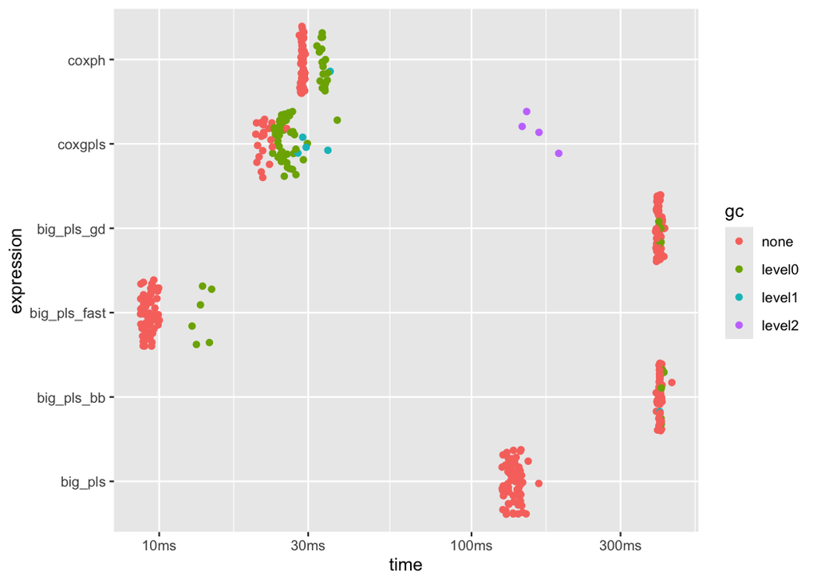

```r
plot(bench_dense, type = "jitter")
```

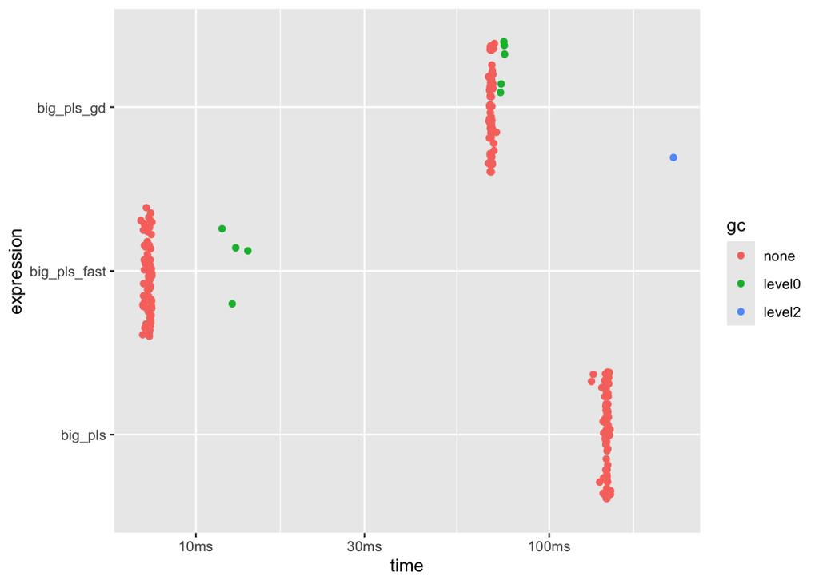

```r
plot(bench_big, type = "jitter")
```

# Exporting benchmark tables

To integrate the benchmark with automated pipelines, store the results under the `inst/benchmarks/` directory. Each run can include meta-data such as dataset parameters, number of iterations, or git commit identifiers.

```r
if (!dir.exists("inst/benchmarks/results")) {
  dir.create("inst/benchmarks/results", recursive = TRUE)
}
write.csv(bench_dense[, 1:9], file = "inst/benchmarks/results/benchmark-dense.csv", row.names = FALSE)
write.csv(bench_big[, 1:9], file = "inst/benchmarks/results/benchmark-big.csv", row.names = FALSE)
```

# Additional scripts

The package also ships with standalone scripts under `inst/benchmarks/` that mirror this vignette while exposing additional configuration points. Run them from the repository root as:

```bash
Rscript inst/benchmarks/cox-benchmark.R
Rscript inst/benchmarks/benchmark_bigPLScox.R
Rscript inst/benchmarks/cox_pls_benchmark.R
```

Each script accepts environment variables to adjust the problem size and stores results in `inst/benchmarks/results/` with time-stamped filenames.